# Chadeau_Valerie_2_notebook_analyse_042022

### * Eboulis des valeurs propres

```
[1639.9999999999998, 1352.3575554083243, 1128.3644393224463, 946.4376979384174, 850.2798212822306, 754.9137767354123, 714.576323144104, 630.2111271996274, 575.8271762344727, 535.0796764067303, 485.6819414171541, 458.962633698446, 437.86723014451843, 415.7966092674358]
```

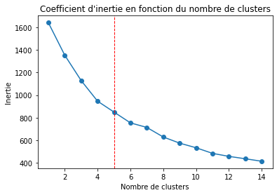

```python
#Calcul des coefficients d'inertie et utilisation méthode du coude (éboulis des valeurs propres)

X = df_volaille.values
# Centrage et Réduction des données afin qu'elles aient le même poids
std_scale = preprocessing.StandardScaler().fit(X)
X_cr = std_scale.transform(X)


inertia=[] #Liste coût du modèle
K_range=range(1,15)
for k in K_range:
    #model=KMeans(n_clusters=k).fit(X_cr) #On entraine le modèle
    model=KMeans(n_clusters=k,max_iter=50, random_state=2000).fit(X_cr) #On entraine le modèle
    inertia.append(model.inertia_) #Cacul du coût du modèle + mémorisation dans liste
memo=plt.plot(K_range,inertia,marker='o')
memo=plt.xlabel('Nombre de clusters')
memo=plt.ylabel('Inertie')
memo=plt.title("Coefficient d'inertie en fonction du nombre de clusters")
memo=plt.axvline(x = 5.0, color ="red", linestyle ="--", linewidth=1)
print(inertia)
```

==> Méthode du coude : à partir de 5 la courbe diminue moins rapidement.  
Le résultat est légèrement différent de celui de la méthode silhouette. On compare le clustering avec 5 et 6 groupes :

```python
#Clustering K-Means en 5 clusters

Cluster5 = cluster.KMeans(n_clusters=5,max_iter=50, random_state=2000)
Cluster5.fit(X_cr)

np.unique(Cluster5.labels_,return_counts=True)

df_kmeans5=df_volaille.copy()
df_kmeans5['Cluster']=Cluster5.labels_



#Clustering K-Means en 6 clusters

Cluster6 = cluster.KMeans(n_clusters=6,max_iter=50, random_state=2000)
Cluster6.fit(X_cr)

np.unique(Cluster6.labels_,return_counts=True)

df_kmeans6=df_volaille.copy()
df_kmeans6['Cluster']=Cluster6.labels_
```

```
KMeans(max_iter=50, n_clusters=5, random_state=2000)
```

```
(array([0, 1, 2, 3, 4]), array([51,  4, 51, 39, 19], dtype=int64))
```

```
KMeans(max_iter=50, n_clusters=6, random_state=2000)
```

```
(array([0, 1, 2, 3, 4, 5]), array([50, 21, 45,  1,  4, 43], dtype=int64))
```

Pour la répartition en 6 clusters, il y a un cluster avec 1 seul pays ce qui n'est pas souhaitable.  
**On conservera la répartition en 5 clusters.**

```python
#Affichage du contenu des 5 clusters

for i in range(0,5):
    list_tempo=df_kmeans5[df_kmeans5['Cluster']==i].index.tolist()
    list_tempo.sort(key=str.lower)
    print('\n Cluster',i,'/ Nombre de pays :',len(list_tempo))
    print('----------------------------------\n')
    print(list_tempo)
```

```
 Cluster 0 / Nombre de pays : 51
----------------------------------

['Albanie', 'Allemagne', 'Arménie', 'Australie', 'Autriche', 'Belgique', 'Bosnie-Herzégovine', 'Bulgarie', 'Bélarus', 'Cabo Verde', 'Canada', 'Chine, Taiwan Province de', 'Chypre', 'Croatie', 'Cuba', 'Danemark', 'Espagne', 'Estonie', 'Finlande', 'Fédération de Russie', 'Grèce', 'Géorgie', 'Hongrie',…

 Cluster 1 / Nombre de pays : 4
----------------------------------

['Brésil', 'Chine, continentale', 'Inde', "États-Unis d'Amérique"]

 Cluster 2 / Nombre de pays : 51
----------------------------------

['Afghanistan', 'Algérie', 'Angola', 'Azerbaïdjan', 'Bangladesh', 'Botswana', 'Burkina Faso', 'Cambodge', 'Cameroun', "Côte d'Ivoire", 'Eswatini', 'Gambie', 'Ghana', 'Guinée', 'Guinée-Bissau', 'Haïti', 'Kenya', 'Kirghizistan', 'Madagascar', 'Malawi', 'Mali', 'Mauritanie', 'Mongolie', 'Mozambique', '…

 Cluster 3 / Nombre de pays : 39
----------------------------------

['Afrique du Sud', 'Argentine', 'Belize', 'Bolivie (État plurinational de)', 'Bénin', 'Chili', 'Colombie', 'Congo', 'Costa Rica', 'El Salvador', 'Fidji', 'Gabon', 'Guatemala', 'Guyana', 'Honduras', 'Indonésie', "Iran (République islamique d')", 'Iraq', 'Israël', 'Jordanie', 'Kiribati', 'Liban', 'Lib…

 Cluster 4 / Nombre de pays : 19
----------------------------------

['Antigua-et-Barbuda', 'Arabie saoudite', 'Bahamas', 'Barbade', 'Chine - RAS de Hong-Kong', 'Chine - RAS de Macao', 'Dominique', 'Grenade', 'Jamaïque', 'Koweït', 'Malaisie', 'Maurice', 'Saint-Kitts-et-Nevis', 'Saint-Vincent-et-les Grenadines', 'Sainte-Lucie', 'Samoa', 'Suriname', 'Trinité-et-Tobago'…
```

### * Constitution du dataframe spécifique aux centroides des 5 clusters obtenus

```python
centroides=Cluster5.cluster_centers_
df_centroides=pd.DataFrame(centroides, columns=df_volaille.columns)
df_centroides
```

|  | Production | % volaille dans la nourriture totale | % volaille dans la consommation de viande totale | TDI | Population 2017 | Variation population 2016-2017 (%) | PIB 2017 ($) | Indice stabilité politique 2017 | Variation taux de change 2016-2017 (%) | % UGB de 2017 |
| --- | --- | --- | --- | --- | --- | --- | --- | --- | --- | --- |
| 0 | -0.093560 | -0.170487 | -0.414914 | 0.212326 | -0.163743 | -0.898476 | 0.760611 | 0.694783 | -0.387119 | -0.360104 |
| 1 | 5.450926 | 0.161839 | 0.106786 | -0.843373 | 4.990350 | -0.471772 | 0.117082 | 0.214903 | -0.377358 | -0.364533 |
| 2 | -0.234044 | -0.805390 | -0.789078 | -0.168406 | -0.065317 | 0.949228 | -0.718078 | -0.694011 | 0.343817 | -0.519984 |
| 3 | -0.017784 | 0.268946 | 0.891578 | -0.405668 | -0.089968 | 0.152323 | -0.356115 | -0.406018 | 0.043481 | 0.465500 |
| 4 | -0.231701 | 2.033341 | 1.379204 | 0.892349 | -0.251084 | -0.349570 | 0.592159 | 0.786091 | 0.106423 | 1.483582 |

### * Comparaison visuelle des clusters par variable avec des boxplots

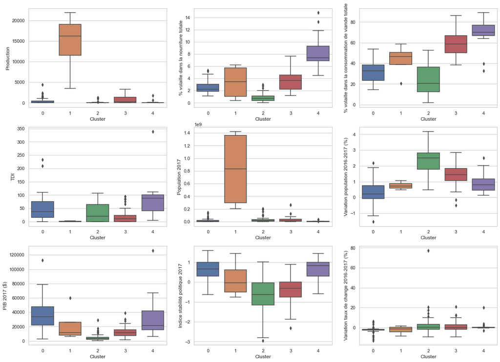

```python
memo=plt.figure(figsize=(20, 20))
memo=sns.set(style="whitegrid")

memo=plt.subplot(431)
memo=sns.boxplot(data=df_kmeans5, x='Cluster', y='Production')

memo=plt.subplot(432)
memo=sns.boxplot(data=df_kmeans5, x='Cluster', y='% volaille dans la nourriture totale')

memo=plt.subplot(433)
memo=sns.boxplot(data=df_kmeans5, x='Cluster', y='% volaille dans la consommation de viande totale')

memo=plt.subplot(434)
memo=sns.boxplot(data=df_kmeans5, x='Cluster', y='TDI')

memo=plt.subplot(435)
memo=sns.boxplot(data=df_kmeans5, x='Cluster', y='Population 2017')

memo=plt.subplot(436)
memo=sns.boxplot(data=df_kmeans5, x='Cluster', y='Variation population 2016-2017 (%)')

memo=plt.subplot(437)
memo=sns.boxplot(data=df_kmeans5, x='Cluster', y='PIB 2017 ($)')

memo=plt.subplot(438)
memo=sns.boxplot(data=df_kmeans5, x='Cluster', y='Indice stabilité politique 2017')


memo=plt.subplot(439)
memo=sns.boxplot(data=df_kmeans5, x='Cluster', y='Variation taux de change 2016-2017 (%)')


memo=plt.show(block=False)
```

**Variable "Production" :** Les pays du cluster 1 sont les plus gros producteurs de volaille  
**Variable "%volaille dans nourriture totale" :** les pays du cluster 4 sont ceux qui consomment le plus de volaille dans leur nourriture  
**Variable "%volaille dans la consommation de viande totale" :** les pays du cluster 4 sont ceux qui consomment le plus de volaille dans leur consommation de viande  
**Variable "TDI" :** Les pays du cluster 4 sont les pays les plus dépendants des importations (forte concurrence à prévoir)  
**Variable "Population 2017" :** Les pays du cluster 1 sont les pays les plus peuplés  
**Variable "Variation Population 2016-2017" :** Les pays du cluster 2 sont ceux qui ont la plus grande variation de population entre 2016 et 2017  
**Variable "PIB 2017" (par habitant) :** Les pays du cluster 0 sont ceux qui ont le plus important PIB par habitant  
**Variable "Indice stabilité politique 2017":** Les pays du cluster 4 sont les pays dont la stabilité politique est la plus importante  
**Variable "Variation taux de change 2016-2017" :** Les pays des clusters 2, 3 et 4 sont ceux qui ont le moins de variation du taux de change

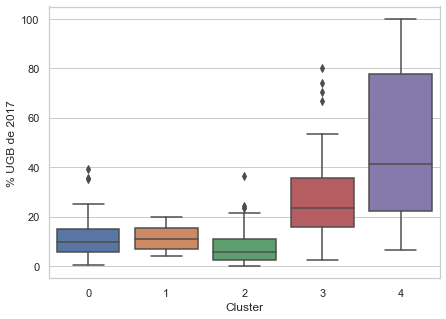

```python
#Comparaison visuelle des clusters par variable avec des boxplots

memo=plt.figure(figsize=(7, 5))
memo=sns.set(style="whitegrid")

#memo=plt.subplot(224)
memo=sns.boxplot(data=df_kmeans5, x='Cluster', y='% UGB de 2017')


memo=plt.show(block=False)
```

**Variable "Variation % UGB 2017" :** Les pays du cluster 4 sont les pays qui ont le % d'élévage de volailles le plus important par rapport aux autres élevages

**==> EN SYNTHESE**

**Cluster 0 :**

- Production : faible
- Consommation viande volaille : moyen
- Population : faible avec peu de variation entre 2016 et 2017
- TDI : assez important
- PIB 2017 : très important
- Indice de stabilité politique : très important
- Variation Taux de change 2016 2017 : négatif
- Part de volaille dans les élevages : faible

**==> mauvais débouchés de ventes : pays consommateurs mais présence concurrence et taux de change négatif : CLUSTER 0 NON RETENU**

**Cluster 1 :**

- Production : très importante
- Consommation viande volaille : forte
- Population : très nombreuse avec faible croissance
- TDI : faible mais fluctuant (50% des pays qui représente entre 0 et 20% de TDI)
- PIB 2017 : dans la moyenne mais disparité entre pays
- Indice de stabilité politique : bon
- Variation Taux de change 2016 2017 : légèrement négatif (produits importés plus chers donc moins de vente)
- Part de volaille dans les élevages : une quantité d'élevage peu importante dans ces pays

**==> mauvais débouchés de ventes : pays très consommateurs mais auto-suffisants : CLUSTER 1 NON RETENU**

**Cluster 2 :**

- Production : faible
- Consommation viande volaille : faible
- Population : faible mais forte variation entre 2016 et 2017
- TDI : faible
- PIB 2017 : faible
- Indice de stabilité politique : faible
- Variation Taux de change 2016 2017 : stable
- Part de volaille dans les élevages : faible

**==> mauvais débouché de ventes : pays peu consommateurs de volaille et PIB faible : CLUSTER 2 NON RETENU**

**Cluster 3 :**

- Production : faible
- Consommation viande volaille : importante
- Population : faible avec peu de croissance
- TDI : peu élevée
- PIB 2017 : moyen
- Indice de stabilité politique : faible et fluctuant (à étudier par pays)
- Variation Taux de change 2016 2017 : stable
- Part de volaille dans les élevages : importante

**==> bon débouché de ventes, PIB suffisant, faible concurrence et taux de change favorable : CLUSTER 3 RETENU**

**Cluster 4 :**

- Production : faible
- Consommation viande volaille : forte
- Population : faible avec peu de croissance
- TDI : forte
- PIB 2017 :élevé
- Indice de stabilité politique : élevé
- Variation Taux de change 2016 2017 : stable
- Part de volaille dans les élevages : très importante

**==> mauvais débouchés de ventes : pays consommateurs mais présence forte concurrence : CLUSTER 4 NON RETENU**

Les 39 pays du cluster 3 peuvent être un débouché de ventes. Une étude affinée des pays doit être réalisée car il existe une grande dispersion de données au sein des différentes variables.

### **b) Constitution de la classification Ascendante Hiérarchique (CAH)**

### * Constitution dendrogramme

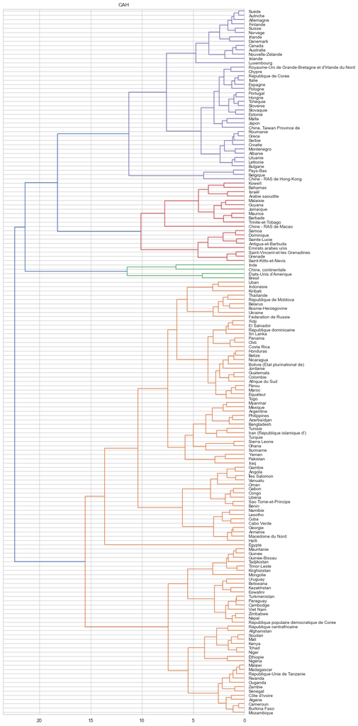

```python
# Clustering hiérarchique avec méthode de Ward (regroupement de 2 clusters avec minimisation de l'inertie intraclasse
#à chaque itération)
Z = linkage(X_cr, method='ward',metric='euclidean')


#Affichage du dendrogramme

memo=plt.figure(figsize=(10,30))
memo=plt.title("CAH")
memo=dendrogram(Z,labels=df_volaille.index,orientation='left',leaf_font_size=10)
memo=plt.show()
```

### * Choix du partitionnement : scree plot

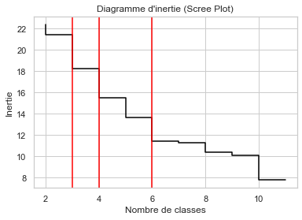

```python
#Constitution d'un screeplot afin de savoir commment partitionner le dendrogramme
#Récupération des 10 dernières valeurs du tableau d'inertie
last=Z[-10:, 2]
last_rev = last[::-1]
#Création des index (=nombre de classes)
idxs = np.arange(2, len(last) + 2)
memo=plt.step(idxs, last_rev, c="black")
memo=plt.xlabel("Nombre de classes")
memo=plt.ylabel("Inertie")
memo=plt.title("Diagramme d'inertie (Scree Plot)")
nombre = 3
#Affichage des sauts d'inertie
memo=plt.axvline(idxs[np.where(idxs==3)], c="red")
memo=plt.axvline(idxs[np.where(idxs==4)], c="red")
memo=plt.axvline(idxs[np.where(idxs==6)], c="red")
memo=plt.show()
```

D'après le diagramme d'inertie : 3 grands sauts d'inertie pour 3, 4 et 6 classes.  
Pour 3 et 4 classes : nécessité d'affiner le choix des pays ==> Trop peu de classes. **On choisit donc 6 classes.**

```python
#Coupage du dendrogramme en 6 classes
groupes_cah = cah.fcluster(Z,t=6,criterion='maxclust')
indices = np.argsort(groupes_cah)
df_cluster_pays_cah=pd.DataFrame(groupes_cah[indices], df_volaille.index[indices])

#Affichage répartition des pays par classe
for i in range(1,7):
    list_tempo=df_cluster_pays_cah[df_cluster_pays_cah[0]==i].index.tolist()
    list_tempo.sort(key=str.lower)
    print('\nCluster ',i,'/ Nombre de pays :',len(list_tempo))
    print('----------------------------------\n')
    print(list_tempo)
```

```
Cluster  1 / Nombre de pays : 39
----------------------------------

['Afghanistan', 'Algérie', 'Botswana', 'Burkina Faso', 'Cambodge', 'Cameroun', "Côte d'Ivoire", 'Eswatini', 'Guinée', 'Guinée-Bissau', 'Kazakhstan', 'Kenya', 'Kirghizistan', 'Madagascar', 'Malawi', 'Mali', 'Mauritanie', 'Mongolie', 'Mozambique', 'Niger', 'Nigéria', 'Népal', 'Ouganda', 'Paraguay', 'R…

Cluster  2 / Nombre de pays : 61
----------------------------------

['Afrique du Sud', 'Angola', 'Argentine', 'Arménie', 'Azerbaïdjan', 'Bangladesh', 'Belize', 'Bolivie (État plurinational de)', 'Bosnie-Herzégovine', 'Bélarus', 'Bénin', 'Cabo Verde', 'Chili', 'Colombie', 'Congo', 'Costa Rica', 'Cuba', 'El Salvador', 'Fidji', 'Fédération de Russie', 'Gabon', 'Gambie'…

Cluster  3 / Nombre de pays : 1
----------------------------------

['Égypte']

Cluster  4 / Nombre de pays : 4
----------------------------------

['Brésil', 'Chine, continentale', 'Inde', "États-Unis d'Amérique"]

Cluster  5 / Nombre de pays : 19
----------------------------------

['Antigua-et-Barbuda', 'Arabie saoudite', 'Bahamas', 'Barbade', 'Chine - RAS de Macao', 'Dominique', 'Grenade', 'Guyana', 'Israël', 'Jamaïque', 'Koweït', 'Malaisie', 'Maurice', 'Saint-Kitts-et-Nevis', 'Saint-Vincent-et-les Grenadines', 'Sainte-Lucie', 'Samoa', 'Trinité-et-Tobago', 'Émirats arabes un…

Cluster  6 / Nombre de pays : 40
----------------------------------

['Albanie', 'Allemagne', 'Australie', 'Autriche', 'Belgique', 'Bulgarie', 'Canada', 'Chine - RAS de Hong-Kong', 'Chine, Taiwan Province de', 'Chypre', 'Croatie', 'Danemark', 'Espagne', 'Estonie', 'Finlande', 'Grèce', 'Hongrie', 'Irlande', 'Islande', 'Italie', 'Japon', 'Lettonie', 'Lituanie', 'Luxemb…
```

Découpage en 6 groupes non satisfaisant (1 classe avec 1 pays) ==> **Choix d'un découpage en 5 classes :**

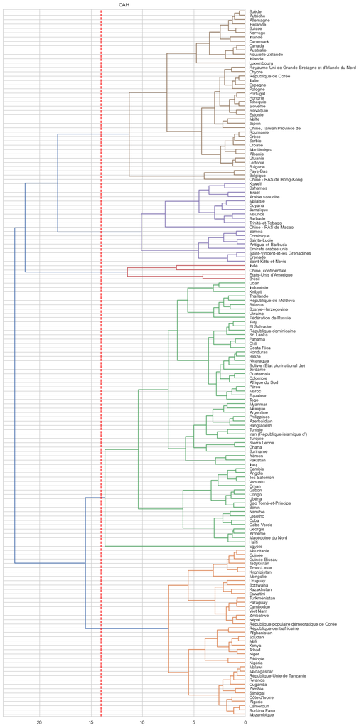

```python
#Coupage du dendrogramme en 5 groupes avec paramètre color_threshold = 14 afin d'avoir 5 groupes
memo=plt.figure(figsize=(10,30))
#memo=plt.figure(figsize=(30,10))
memo=plt.title("CAH")
memo=dendrogram(Z,labels=df_volaille.index,orientation='left',leaf_font_size=10,color_threshold=14)
#memo=dendrogram(Z,labels=df_volaille.index,orientation='top',leaf_font_size=10,color_threshold=14)
memo=plt.axvline(x = 14.0, color ="red", linestyle ="--", linewidth=1.5)
#memo=plt.axhline(y = 14.0, color ="red", linestyle ="--", linewidth=1.5)
memo=plt.savefig('Chadeau_Valerie_11_dendrogramme_042022.jpg')
memo=plt.show()
```

```python
#Récupération des 5 clusters avec la méthode CAH
groupes_cah = cah.fcluster(Z,t=5,criterion='maxclust')
indices = np.argsort(groupes_cah)
df_cluster_pays_cah=pd.DataFrame(groupes_cah[indices], df_volaille.index[indices])

#Affichage répartition des pays par groupe
for i in range(1,6):
    list_tempo=df_cluster_pays_cah[df_cluster_pays_cah[0]==i].index.tolist()
    list_tempo.sort(key=str.lower)
    print('\nCluster ',i,'/ Nombre de pays :',len(list_tempo))
    print('----------------------------------\n')
    print(list_tempo)
```

```
Cluster  1 / Nombre de pays : 39
----------------------------------

['Afghanistan', 'Algérie', 'Botswana', 'Burkina Faso', 'Cambodge', 'Cameroun', "Côte d'Ivoire", 'Eswatini', 'Guinée', 'Guinée-Bissau', 'Kazakhstan', 'Kenya', 'Kirghizistan', 'Madagascar', 'Malawi', 'Mali', 'Mauritanie', 'Mongolie', 'Mozambique', 'Niger', 'Nigéria', 'Népal', 'Ouganda', 'Paraguay', 'R…

Cluster  2 / Nombre de pays : 62
----------------------------------

['Afrique du Sud', 'Angola', 'Argentine', 'Arménie', 'Azerbaïdjan', 'Bangladesh', 'Belize', 'Bolivie (État plurinational de)', 'Bosnie-Herzégovine', 'Bélarus', 'Bénin', 'Cabo Verde', 'Chili', 'Colombie', 'Congo', 'Costa Rica', 'Cuba', 'El Salvador', 'Fidji', 'Fédération de Russie', 'Gabon', 'Gambie'…

Cluster  3 / Nombre de pays : 4
----------------------------------

['Brésil', 'Chine, continentale', 'Inde', "États-Unis d'Amérique"]

Cluster  4 / Nombre de pays : 19
----------------------------------

['Antigua-et-Barbuda', 'Arabie saoudite', 'Bahamas', 'Barbade', 'Chine - RAS de Macao', 'Dominique', 'Grenade', 'Guyana', 'Israël', 'Jamaïque', 'Koweït', 'Malaisie', 'Maurice', 'Saint-Kitts-et-Nevis', 'Saint-Vincent-et-les Grenadines', 'Sainte-Lucie', 'Samoa', 'Trinité-et-Tobago', 'Émirats arabes un…

Cluster  5 / Nombre de pays : 40
----------------------------------

['Albanie', 'Allemagne', 'Australie', 'Autriche', 'Belgique', 'Bulgarie', 'Canada', 'Chine - RAS de Hong-Kong', 'Chine, Taiwan Province de', 'Chypre', 'Croatie', 'Danemark', 'Espagne', 'Estonie', 'Finlande', 'Grèce', 'Hongrie', 'Irlande', 'Islande', 'Italie', 'Japon', 'Lettonie', 'Lituanie', 'Luxemb…
```

```python
#Constitution du dataframe df_cah obtenu avec les données issus du clustering CAH
df_cah = pd.merge(df_volaille, df_cluster_pays_cah, on='Pays').reset_index()
df_cah.rename(columns={0:'Cluster'},inplace=True)
df_cah.head()
df_cah.dtypes
```

|  | Pays | Production | % volaille dans la nourriture totale | % volaille dans la consommation de viande totale | TDI | Population 2017 | Variation population 2016-2017 (%) | PIB 2017 ($) | Indice stabilité politique 2017 | Variation taux de change 2016-2017 (%) | % UGB de 2017 | Cluster |
| --- | --- | --- | --- | --- | --- | --- | --- | --- | --- | --- | --- | --- |
| 0 | Afghanistan | 28.0 | 0.4 | 17.6 | 50.88 | 36296113.0 | 2.58 | 2058.4 | -2.80 | 0.24 | 2.04 | 1 |
| 1 | Afrique du Sud | 1667.0 | 6.4 | 59.5 | 24.27 | 57009756.0 | 1.43 | 12701.3 | -0.28 | -9.35 | 12.28 | 2 |
| 2 | Albanie | 13.0 | 1.3 | 34.6 | 74.51 | 2884169.0 | -0.08 | 12771.0 | 0.38 | -4.06 | 10.54 | 5 |
| 3 | Algérie | 275.0 | 0.8 | 35.3 | 0.72 | 41389189.0 | 2.07 | 11737.4 | -0.92 | 1.40 | 21.30 | 1 |
| 4 | Allemagne | 1514.0 | 2.1 | 22.2 | 49.24 | 82658409.0 | 0.57 | 52952.9 | 0.59 | -2.08 | 7.99 | 5 |

```
Pays                                                 object
Production                                          float64
% volaille dans la nourriture totale                float64
% volaille dans la consommation de viande totale    float64
TDI                                                 float64
Population 2017                                     float64
Variation population 2016-2017 (%)                  float64
PIB 2017 ($)                                        float64
Indice stabilité politique 2017                     float64
Variation taux de change 2016-2017 (%)              float64
% UGB de 2017                                       float64
Cluster                                               int32
dtype: object
```

### * Comparaison visuelle des clusters par variable avec des boxplots

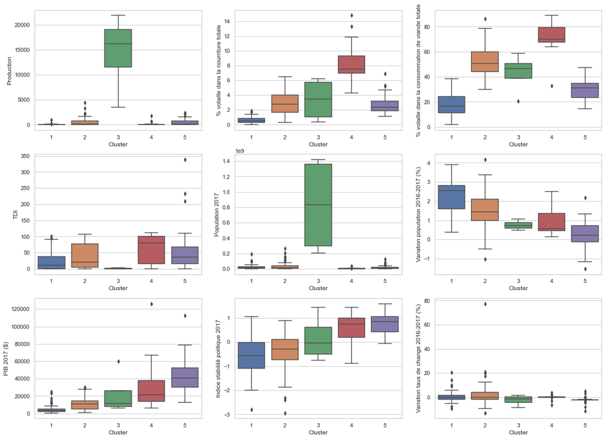

```python
#Comparaison visuelle des clusters par variable avec des boxplots
memo=plt.figure(figsize=(20, 20))
memo=sns.set(style="whitegrid")

memo=plt.subplot(431)
memo=sns.boxplot(data=df_cah, x='Cluster', y='Production')

memo=plt.subplot(432)
memo=sns.boxplot(data=df_cah, x='Cluster', y='% volaille dans la nourriture totale')

memo=plt.subplot(433)
memo=sns.boxplot(data=df_cah, x='Cluster', y='% volaille dans la consommation de viande totale')

memo=plt.subplot(434)
memo=sns.boxplot(data=df_cah, x='Cluster', y='TDI')

memo=plt.subplot(435)
memo=sns.boxplot(data=df_cah, x='Cluster', y='Population 2017')

memo=plt.subplot(436)
memo=sns.boxplot(data=df_cah, x='Cluster', y='Variation population 2016-2017 (%)')

memo=plt.subplot(437)
memo=sns.boxplot(data=df_cah, x='Cluster', y='PIB 2017 ($)')

memo=plt.subplot(438)
memo=sns.boxplot(data=df_cah, x='Cluster', y='Indice stabilité politique 2017')


memo=plt.subplot(439)
memo=sns.boxplot(data=df_cah, x='Cluster', y='Variation taux de change 2016-2017 (%)')





memo=plt.show(block=False)
```

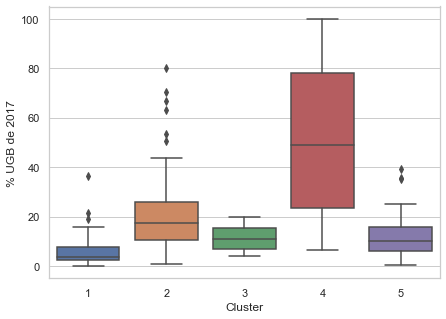

```python
#Comparaison visuelle des clusters par variable avec des boxplots

memo=plt.figure(figsize=(7, 5))
memo=sns.set(style="whitegrid")

#memo=plt.subplot(224)
memo=sns.boxplot(data=df_cah, x='Cluster', y='% UGB de 2017')


memo=plt.show(block=False)
```

**Variable "Variation % UGB 2017" :** Les pays du cluster 4 sont les pays qui ont le % d'élévage de volailles le plus important par rapport aux autres élevages

**==> EN SYNTHESE**

**Cluster 1 :**

- Production : faible
- Consommation viande volaille : faible
- Population : faible mais forte variation entre 2016 et 2017
- TDI : faible
- PIB 2017 : faible
- Indice de stabilité politique : faible
- Variation Taux de change 2016 2017 : stable
- Part de volaille dans les élevages : faible

**==> faible débouché de ventes et PIB faible : CLUSTER 1 NON RETENU**

**Cluster 2 :**

- Production : faible
- Consommation viande volaille : forte
- Population : faible mais variation entre 2016 et 2017 qui peut être importante
- TDI : faible mais fluctuant (50% des pays qui représente entre 0 et 20% de TDI)
- PIB 2017 : peu élevé mais assez fluctuant par pays
- Indice de stabilité politique : faiblement négatif pour 50% des pays
- Variation Taux de change 2016 2017 : stable
- Part de volaille dans les élevages : une quantité d'élevage important dans ces pays mais reste raisonnable (inférieure à 20% pour 50% des pays)

**==> bon débouché de ventes, PIB suffisant, faible concurrence et taux de change favorable : CLUSTER 2 RETENU**

**Cluster 3 :**

- Production : très importante
- Consommation viande volaille : forte
- Population : très nombreuse avec faible croissance
- TDI : faible mais fluctuant (50% des pays qui représente entre 0 et 20% de TDI)
- PIB 2017 : moyennant élevé mais qui peut être très important
- Indice de stabilité politique : bon
- Variation Taux de change 2016 2017 : légèrement négatif (produits importés plus chers donc moins de vente)
- Part de volaille dans les élevages : une quantité d'élevage peu importante dans ces pays

**==> mauvais débouchés de ventes : pays très consommateurs mais auto-suffisants : CLUSTER 3 NON RETENU**

**Cluster 4 :**

- Production : faible
- Consommation viande volaille : importante
- Population : faible avec peu de croissance
- TDI : forte
- PIB 2017 : important
- Indice de stabilité politique : bon
- Variation Taux de change 2016 2017 : légèrement négatif (produits importés plus chers donc moins de vente)
- Part de volaille dans les élevages : très fort

**==> mauvais débouchés de ventes : pays très consommateurs mais forte concurrence : CLUSTER 4 NON RETENU**

**Cluster 5 :**

- Production : faible
- Consommation viande volaille : moyenne
- Population : faible avec peu de croissance
- TDI : moyenne
- PIB 2017 :très élevé
- Indice de stabilité politique : très élevé
- Variation Taux de change 2016 2017 : négatif (produits importés plus chers donc moins de vente)
- Part de volaille dans les élevages : moyen

**==> mauvais débouchés de ventes : pays consommateurs mais présence concurrence et taux de change négatif : CLUSTER 5 NON RETENU**

Les 62 pays du cluster 2 peuvent être un débouché de ventes. Une étude affinée des pays doit être réalisée car il existe une grande dispersion de données au sein des différentes variables.

### **c) Liste des pays retenus**

Il s'agit des pays communs aux 2 méthodes de clustering : il s'agit de pays émergents.

```python
choix_kmeans=df_kmeans5.loc[df_kmeans5['Cluster']==3]
choix_cah=df_cah.loc[df_cah['Cluster']==2]

liste_pays=pd.merge(choix_kmeans,choix_cah, how='inner', on=['Pays'])

print(liste_pays.shape[0]," pays retenus : \n")
print(liste_pays['Pays'].to_markdown(index=False,tablefmt="grid"))
```

```
37  pays retenus :

+---------------------------------+
| Pays                            |
+=================================+
| Afrique du Sud                  |
+---------------------------------+
| Argentine                       |
+---------------------------------+
| Belize                          |
+---------------------------------+
| Bolivie (État plurinational de) |
+---------------------------------+
| Bénin                           |
+---------------------------------+
| Chili                           |
+---------------------------------+
| Colombie                        |
+---------------------------------+
| Congo                           |
+---------------------------------+
| Costa Rica                      |
+---------------------------------+
| El Salvador                     |
+---------------------------------+
| Fidji                           |
+---------------------------------+
| Gabon                           |
+---------------------------------+
| Guatemala                       |
+---------------------------------+
| Honduras                        |
+---------------------------------+
| Indonésie                       |
+---------------------------------+
| Iran (République islamique d')  |
+---------------------------------+
| Iraq                            |
+---------------------------------+
| Jordanie                        |
```

[output cut: 24 more lines]

```
+---------------------------------+
| Sri Lanka                       |
+---------------------------------+
| Thaïlande                       |
+---------------------------------+
| Togo                            |
+---------------------------------+
| Tunisie                         |
+---------------------------------+
| Turquie                         |
+---------------------------------+
| Ukraine                         |
+---------------------------------+
| Équateur                        |
+---------------------------------+
```

### ANALYSE EN COMPOSANTES PRINCIPALES

Elle va nous permettre de faire l'analyse des liens entre les variables : on recherche la projection dans un repère pour laquelle l'inertie des points est maximale. Deux objectifs : 1. Etude de la variabilité des individus 2. Etude de la liaison entre les variables Elle nous permettra également de faire une confirmation de nos résultats obtenus précédemment.

### * Définition du nombre de composantes nécessaires pour la projection des données

```
PCA(n_components=10)
```

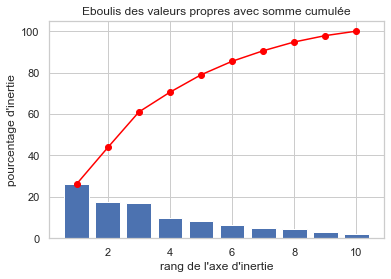

```
Variance expliquée pour chaque axe :
[26.26978266 17.5639927  17.14503006  9.54570562  8.39811738  6.52825688
  5.07699316  4.24577165  3.07377607  2.15257383]
==>Variance expliquée cumulée pour chaque axe :
[ 26.26978266  43.83377536  60.97880542  70.52451104  78.92262842
  85.4508853   90.52787846  94.7736501   97.84742617 100.        ]

Valeur propre pour chaque axe :
[2.6430947  1.76717473 1.72502143 0.96042682 0.84496396 0.65683075
 0.51081404 0.42718193 0.30926336 0.21657798]
```

```python
# Affichage éboulis des valeurs propres : évolution de l’inertie expliquée par les axes

#Calcul des composantes principales
model_pca = decomposition.PCA(n_components=10)
model_pca.fit(X_cr)

#Eboulis des valeurs propres
display_scree_plot(model_pca)

#Affichage pour chaque axe de la variance expliquée  et des valeurs propres
print("Variance expliquée pour chaque axe : ")
print (model_pca.explained_variance_ratio_*100)
print("==>Variance expliquée cumulée pour chaque axe : ")
print (np.cumsum(model_pca.explained_variance_ratio_*100))
print("\nValeur propre pour chaque axe : ")
print(model_pca.explained_variance_)
```

On applique la méthode "du coude" qui nous permet de voir à quel endroit de la courbe le pourcentage d’inertie diminue beaucoup plus lentement.Ici c'est à partir du 3ème rang. En utilisant avec une eutre méthode, le critère de Kayser : pas de prise en compte des axes dont l’inertie associée est inférieure à (100/p)% avec p=10 soit 100/10 = 10 (ces axes représentent moins de variabilité qu’une seule variable initiale). Les 3 premiers axes permettent d'expliquer environ 61% de la variance des données.

### * Cercles de corrélation & projection sur plan factoriel

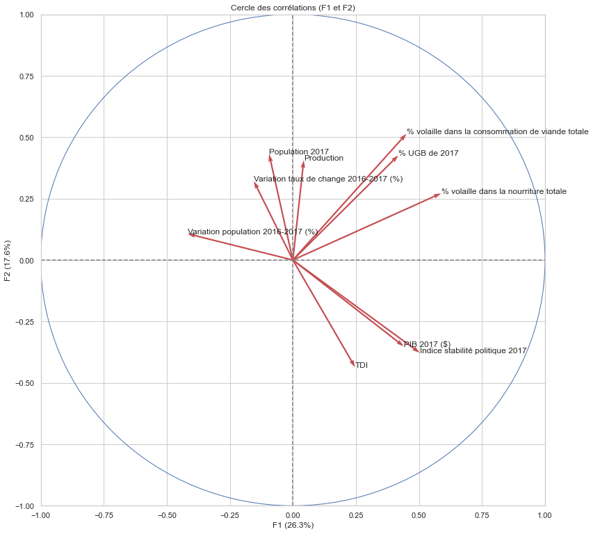

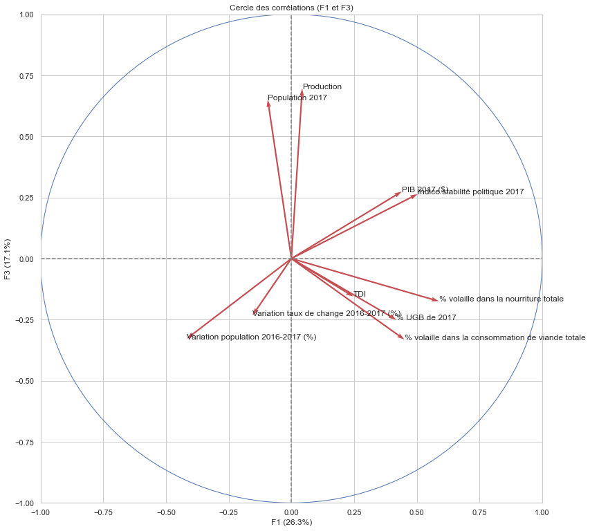

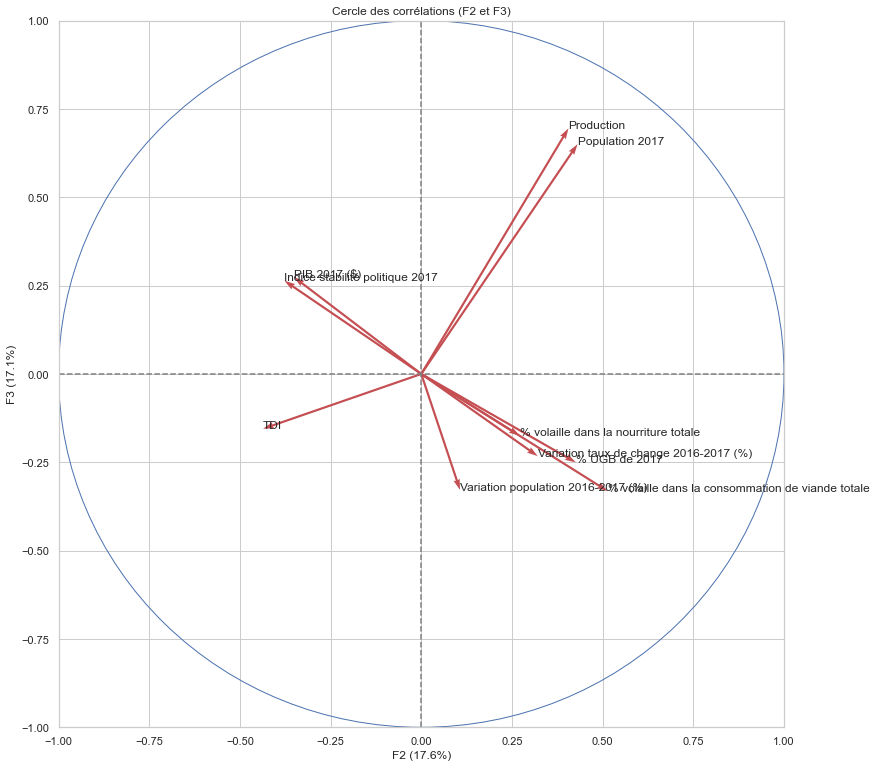

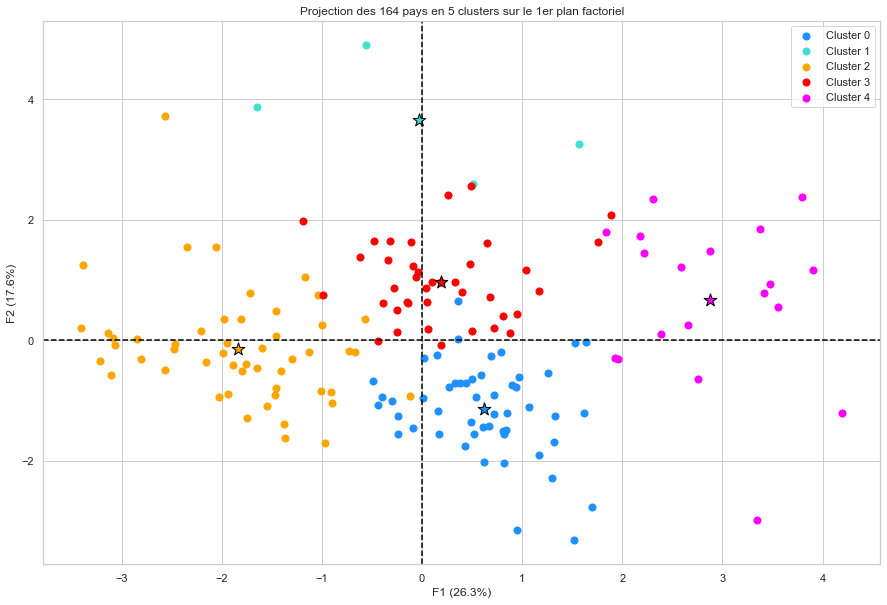

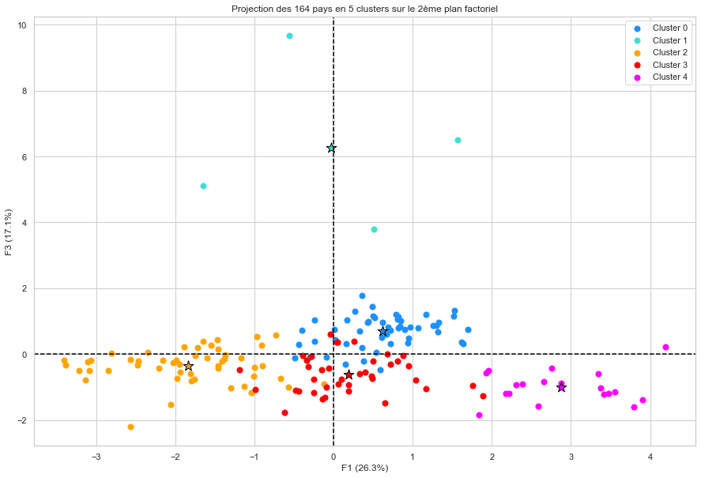

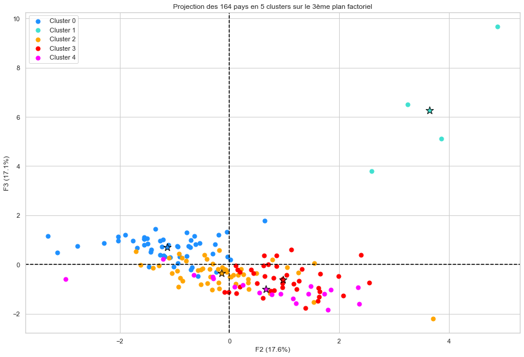

```python
# Affichage du cercle de corrélation du 1er plan avec les composantes F1 et F2
pcs = model_pca.components_
display_circles(pcs, 5, model_pca, [(0,1),(0,2),(1,2)], labels = np.array(df_volaille.columns))


#Coordonnées factorielles
X_projected = model_pca.transform(X_cr)
centroides_projected = model_pca.transform(centroides)


colors = np.array(["dodgerblue", "turquoise","orange","red","magenta"])
i=1

for d1,d2 in [(0,1),(0,2),(1,2)]:
    memo=plt.figure(figsize=(15, 10))
    for value in np.unique(Cluster5.labels_):
        selected = np.where(Cluster5.labels_ == value)
        memo=plt.scatter(X_projected[selected, d1], X_projected[selected,d2],c=colors[value],label='Cluster ' + str(value),s=50)
        memo=plt.scatter(centroides_projected[value,d1],centroides_projected[value,d2],c=colors[value],marker = '*',
                         edgecolors = 'black',s=180)

    #memo=plt.scatter(centroides_projected[:,0],centroides_projected[:,1],c='black',marker = '*',s=110)

    memo=plt.legend()
    memo=plt.xlabel('F{} ({}%)'.format(d1+1, round(100*model_pca.explained_variance_ratio_[d1],1)))
    memo=plt.ylabel('F{} ({}%)'.format(d2+1, round(100*model_pca.explained_variance_ratio_[d2],1)))
    if i==1 :
        numplan="1er"
    else:
        numplan=str(i)+"ème"
    i=i+1


    #memo=plt.title("Projection des {} pays en 5 clusters sur le ".format(X_projected.shape[0]),numplan, " plan factoriel")
    memo=plt.title("Projection des {} pays en 5 clusters sur le {} plan factoriel".format(X_projected.shape[0],numplan))
    memo=plt.axvline(x = 0, color ="black", linestyle ="--", linewidth=1.5)
    memo=plt.axhline(y = 0, color ="black", linestyle ="--", linewidth=1.5)
    memo=plt.show()
```

### Constitution du heatmap entre les centroïdes des clusters de pays et les variables

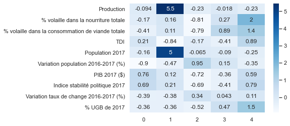

```
 LISTE DES CLUSTERS AVEC PAYS

Cluster  0 / Nombre de pays : 51

 ['Albanie', 'Allemagne', 'Arménie', 'Australie', 'Autriche', 'Belgique', 'Bosnie-Herzégovine', 'Bulgarie', 'Bélarus', 'Cabo Verde', 'Canada', 'Chine, Taiwan Province de', 'Chypre', 'Croatie', 'Cuba', 'Danemark', 'Espagne', 'Estonie', 'Finlande', 'Fédération de Russie', 'Grèce', 'Géorgie', 'Hongrie'…

Cluster  1 / Nombre de pays : 4

 ['Brésil', 'Chine, continentale', 'Inde', "États-Unis d'Amérique"]

Cluster  2 / Nombre de pays : 51

 ['Afghanistan', 'Algérie', 'Angola', 'Azerbaïdjan', 'Bangladesh', 'Botswana', 'Burkina Faso', 'Cambodge', 'Cameroun', "Côte d'Ivoire", 'Eswatini', 'Gambie', 'Ghana', 'Guinée', 'Guinée-Bissau', 'Haïti', 'Kenya', 'Kirghizistan', 'Madagascar', 'Malawi', 'Mali', 'Mauritanie', 'Mongolie', 'Mozambique', …

Cluster  3 / Nombre de pays : 39

 ['Afrique du Sud', 'Argentine', 'Belize', 'Bolivie (État plurinational de)', 'Bénin', 'Chili', 'Colombie', 'Congo', 'Costa Rica', 'El Salvador', 'Fidji', 'Gabon', 'Guatemala', 'Guyana', 'Honduras', 'Indonésie', "Iran (République islamique d')", 'Iraq', 'Israël', 'Jordanie', 'Kiribati', 'Liban', 'Li…

Cluster  4 / Nombre de pays : 19

 ['Antigua-et-Barbuda', 'Arabie saoudite', 'Bahamas', 'Barbade', 'Chine - RAS de Hong-Kong', 'Chine - RAS de Macao', 'Dominique', 'Grenade', 'Jamaïque', 'Koweït', 'Malaisie', 'Maurice', 'Saint-Kitts-et-Nevis', 'Saint-Vincent-et-les Grenadines', 'Sainte-Lucie', 'Samoa', 'Suriname', 'Trinité-et-Tobago…
```

```python
memo=sns.heatmap(np.transpose(df_centroides), cmap="Blues",annot = True)
memo=plt.show()
#Affichage du contenu des 5 clusters
print('\n LISTE DES CLUSTERS AVEC PAYS\n')
for i in range(0,5):
    list_tempo=df_kmeans5[df_kmeans5['Cluster']==i].index.tolist()
    list_tempo.sort(key=str.lower)
    print('Cluster ',i,'/ Nombre de pays :',len(list_tempo),'\n\n',list_tempo,'\n')
```

### Constitution du clustermap entre les pays et les variables

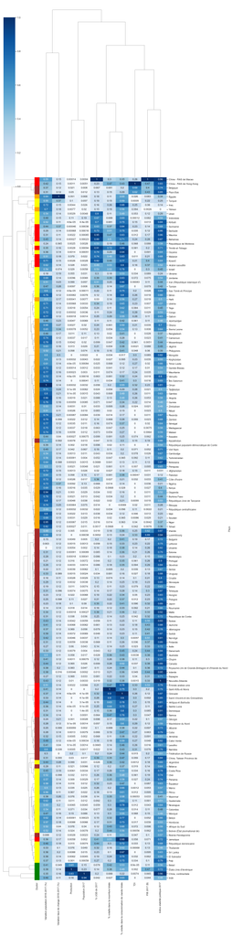

```python
#Constitution heatmap : colorisation des classes pour comparaison du résultat du clustering et de kmeans
df_cr['Cluster']=df_kmeans5['Cluster']
#df_cr=df_cr.sort_values(by = 'Cluster')
my_palette = dict(zip(df_cr['Cluster'].unique(), ["orange","yellow","brown","red","green"]))
row_colors = df_cr['Cluster'].map(my_palette)
memo=plt.figure(figsize=(20, 30))
#sns.clustermap(temp, method="ward", metric="euclidean", cmap="Blues", standard_scale=1, row_colors=row_colors)
memo=sns.clustermap(df_cr.iloc[:,0:10], figsize=(15,60), cmap = 'Blues',annot=True, standard_scale=1, metric="correlation",row_colors=row_colors)
#memo=sns.clustermap(df_cr.iloc[:,0:10], figsize=(15,60), cmap = 'Blues',annot=True, method="ward", metric="euclidean",row_colors=row_colors)
memo=plt.savefig('Chadeau_Valerie_12_clustermap_042022.jpg')
```

==> Il nous permet de valider le poids de certains pays sur des variables (exemple : la Chine qui a un poids important dans la "Population" ou les Etats-Unis dans la "Production)

### CONCLUSION

Après analyse exploratoire :  
*découpage des pays en **5 clusters** avec méthodes KMeans et CAH ***37 pays retenus** communs aux 2 méthodes de partitionnement qui sont des pays émergents répondant aux critères suivants :

Consommation de volaille élevé ==> débouchés de vente élevé

Indice de stabilité politique correct ==> probabilité de remise en question du négoce faible

Production faible ==> peu de concurrence

TDI faible ==> peu de concurrence

PIB moyen ==> pouvoir d’achat existant

Taux de change stable ==> pas de fluctuation de prix inquiétante

***ACP à 61%** de variance expliquée